# Description and Context

Businesses like banks that provide service have to worry about the problem of 'Churn' i.e. customers leaving and joining another service provider. It is important to understand which aspects of the service influence a customer's decision in this regard. Management can concentrate efforts on the improvement of service, keeping in mind these priorities.

## Objective

Given a Bank customer, build a neural network-based classifier that can determine whether they will leave or not in the next 6 months.

## Data Description

The case study is from an open-source dataset from Kaggle. The dataset contains 10,000 sample points with 14 distinct features such as CustomerId, CreditScore, Geography, Gender, Age, Tenure, Balance, etc.

- RowNumber: Row number.
- CustomerId: Unique identification key for different customers.
- Surname: Surname of the customer
- Credit Score: A credit score is a measure of an individual's ability to pay back the borrowed amount. It is the numerical representation of their creditworthiness. A credit score is a 3-digit number that falls in the range of 300-900, 900 being the highest.
- Geography: The country to which the customer belongs.
- Gender: The gender of the customer.
- Age: Age of the customer.
- Tenure: The period of time a customer has been associated with the bank.
- Balance: The account balance (the amount of money deposited in the bank account) of the customer.
- NumOfProducts: How many accounts, bank account affiliated products the person has.
- HasCrCard: Does the customer have a credit card through the bank?
- IsActiveMember: Subjective, but for the concept
- EstimatedSalary: Estimated salary of the customer.
- Exited: Did they leave the bank after all?

```python
# Importing libraries

import pandas as pd
import numpy as np
from sklearn.model_selection import train_test_split
import tensorflow as tf
from sklearn import preprocessing
from tensorflow.keras.models import Sequential
from tensorflow.keras.layers import Dense, Dropout
from sklearn.metrics import accuracy_score, confusion_matrix, precision_score, recall_score, f1_score, precision_recall_curve, auc
import matplotlib.pyplot as plt
from tensorflow.keras import optimizers
from sklearn.decomposition import PCA
import seaborn as sns
import keras
import tensorflow as tf
from keras import backend as K
from keras.models import Sequential
from keras.layers import Dense, Dropout
```

```python
#reading dataset
data = pd.read_csv('bank.csv')
```

```python
data.head()
```

|  | RowNumber | CustomerId | Surname | CreditScore | Geography | Gender | Age | Tenure | Balance | NumOfProducts | HasCrCard | IsActiveMember | EstimatedSalary | Exited |
| --- | --- | --- | --- | --- | --- | --- | --- | --- | --- | --- | --- | --- | --- | --- |
| 0 | 1 | 15634602 | Hargrave | 619 | France | Female | 42 | 2 | 0.00 | 1 | 1 | 1 | 101348.88 | 1 |
| 1 | 2 | 15647311 | Hill | 608 | Spain | Female | 41 | 1 | 83807.86 | 1 | 0 | 1 | 112542.58 | 0 |
| 2 | 3 | 15619304 | Onio | 502 | France | Female | 42 | 8 | 159660.80 | 3 | 1 | 0 | 113931.57 | 1 |
| 3 | 4 | 15701354 | Boni | 699 | France | Female | 39 | 1 | 0.00 | 2 | 0 | 0 | 93826.63 | 0 |
| 4 | 5 | 15737888 | Mitchell | 850 | Spain | Female | 43 | 2 | 125510.82 | 1 | 1 | 1 | 79084.10 | 0 |

So far, it seems we can eliminate rownumber, customerid, and surname from the dataset since they are arbitrary and tell us nothing about someone's relationship to the bank

```python
data.drop(columns=['RowNumber','CustomerId', 'Surname'], inplace=True)
```

```python
data.shape
```

```
(10000, 11)
```

Features have dropped from 14 to 11

```python
data.describe()
```

|  | CreditScore | Age | Tenure | Balance | NumOfProducts | HasCrCard | IsActiveMember | EstimatedSalary | Exited |
| --- | --- | --- | --- | --- | --- | --- | --- | --- | --- |
| count | 10000.000000 | 10000.000000 | 10000.000000 | 10000.000000 | 10000.000000 | 10000.00000 | 10000.000000 | 10000.000000 | 10000.000000 |
| mean | 650.528800 | 38.921800 | 5.012800 | 76485.889288 | 1.530200 | 0.70550 | 0.515100 | 100090.239881 | 0.203700 |
| std | 96.653299 | 10.487806 | 2.892174 | 62397.405202 | 0.581654 | 0.45584 | 0.499797 | 57510.492818 | 0.402769 |
| min | 350.000000 | 18.000000 | 0.000000 | 0.000000 | 1.000000 | 0.00000 | 0.000000 | 11.580000 | 0.000000 |
| 25% | 584.000000 | 32.000000 | 3.000000 | 0.000000 | 1.000000 | 0.00000 | 0.000000 | 51002.110000 | 0.000000 |
| 50% | 652.000000 | 37.000000 | 5.000000 | 97198.540000 | 1.000000 | 1.00000 | 1.000000 | 100193.915000 | 0.000000 |
| 75% | 718.000000 | 44.000000 | 7.000000 | 127644.240000 | 2.000000 | 1.00000 | 1.000000 | 149388.247500 | 0.000000 |
| max | 850.000000 | 92.000000 | 10.000000 | 250898.090000 | 4.000000 | 1.00000 | 1.000000 | 199992.480000 | 1.000000 |

- Given the summary of the data, it is likely that IsActiveMember, Balance, and HasCrCard might give us the same information, and maybe removing one of them should be considered later
- Discrepency between median and mean of Balance can be explained by the number of 0 balance customers

```python
data.info()
```

```
<class 'pandas.core.frame.DataFrame'>
RangeIndex: 10000 entries, 0 to 9999
Data columns (total 11 columns):
 #   Column           Non-Null Count  Dtype
---  ------           --------------  -----
 0   CreditScore      10000 non-null  int64
 1   Geography        10000 non-null  object
 2   Gender           10000 non-null  object
 3   Age              10000 non-null  int64
 4   Tenure           10000 non-null  int64
 5   Balance          10000 non-null  float64
 6   NumOfProducts    10000 non-null  int64
 7   HasCrCard        10000 non-null  int64
 8   IsActiveMember   10000 non-null  int64
 9   EstimatedSalary  10000 non-null  float64
 10  Exited           10000 non-null  int64
dtypes: float64(2), int64(7), object(2)
memory usage: 859.5+ KB
```

There are no null values in this set

```python
data.nunique()
```

```
CreditScore         460
Geography             3
Gender                2
Age                  70
Tenure               11
Balance            6382
NumOfProducts         4
HasCrCard             2
IsActiveMember        2
EstimatedSalary    9999
Exited                2
dtype: int64
```

```python
data.value_counts('Exited')
```

```
Exited
0    7963
1    2037
dtype: int64
```

Looks like ~20% of this dataset left the bank

# EDA

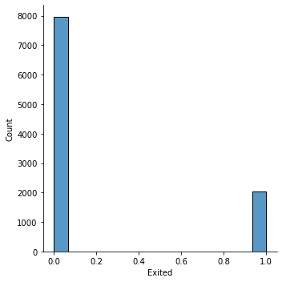

```python
# Visual distribution of target variable exited
plt.figure(figsize=(10,6))
sns.displot(data=data,x='Exited')
```

The dataset is slightly unbalanced, around 4x as many people stayed with the bank as left

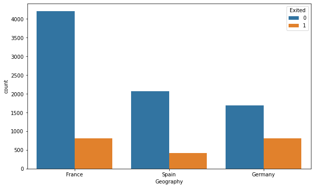

```python
# Visual representation of geography with target variable as hue
plt.figure(figsize=(10,6))
sns.countplot(data=data,x='Geography',hue='Exited')
```

Looks like a disproportionately large amount of people from Germany exited. This variable might be more important than it would seem at first glance.

```python
# One-hot encoding categorical variables
dum_df = pd.get_dummies(data, columns=['Geography','Gender'])
dum_df.head()
```

|  | CreditScore | Age | Tenure | Balance | NumOfProducts | HasCrCard | IsActiveMember | EstimatedSalary | Exited | Geography_France | Geography_Germany | Geography_Spain | Gender_Female | Gender_Male |
| --- | --- | --- | --- | --- | --- | --- | --- | --- | --- | --- | --- | --- | --- | --- |
| 0 | 619 | 42 | 2 | 0.00 | 1 | 1 | 1 | 101348.88 | 1 | 1 | 0 | 0 | 1 | 0 |
| 1 | 608 | 41 | 1 | 83807.86 | 1 | 0 | 1 | 112542.58 | 0 | 0 | 0 | 1 | 1 | 0 |
| 2 | 502 | 42 | 8 | 159660.80 | 3 | 1 | 0 | 113931.57 | 1 | 1 | 0 | 0 | 1 | 0 |
| 3 | 699 | 39 | 1 | 0.00 | 2 | 0 | 0 | 93826.63 | 0 | 1 | 0 | 0 | 1 | 0 |
| 4 | 850 | 43 | 2 | 125510.82 | 1 | 1 | 1 | 79084.10 | 0 | 0 | 0 | 1 | 1 | 0 |

```python
data = dum_df
data.drop(columns=['Gender_Female'], inplace = True)
```

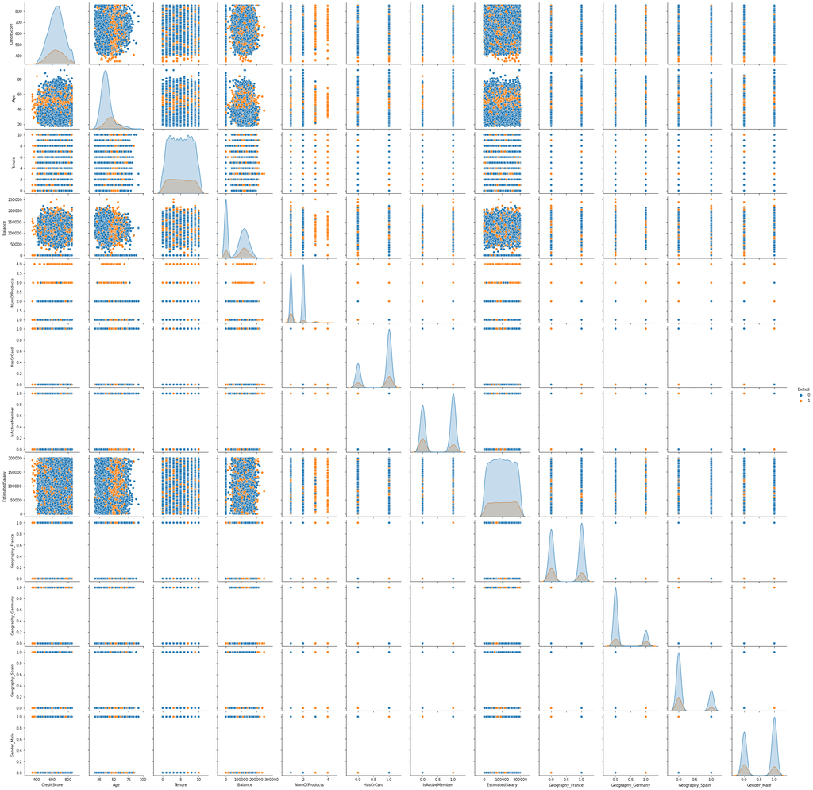

```python
# Pairplot of the data
plt.figure(figsize=(10,6))
sns.pairplot(data,hue='Exited')
```

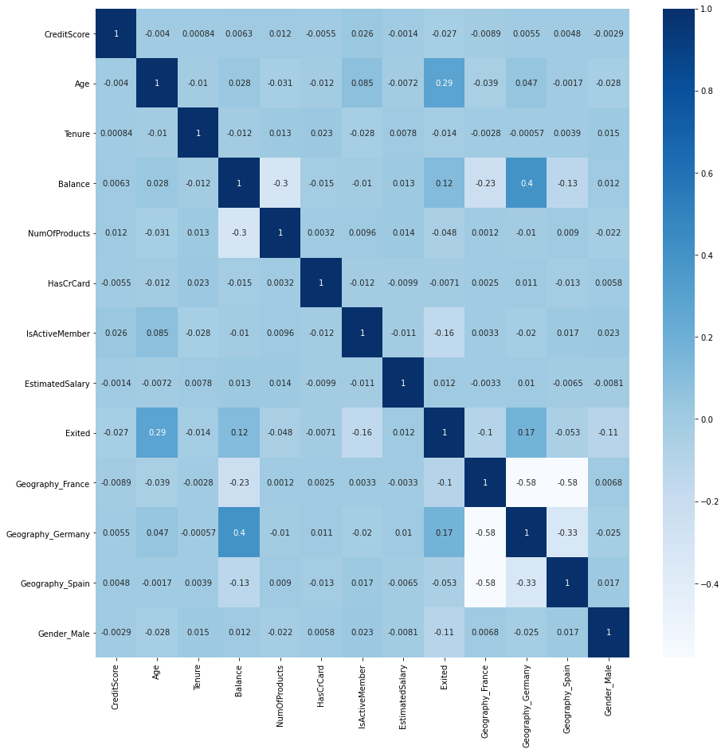

```python
fig, ax = plt.subplots(figsize=(15,15))
sns.heatmap(data.corr(),cmap="Blues",ax=ax,annot=True)
```

- There aren't any especially strong correlations in the data, but we can see that Age is has a slight positive correlation with Exited
- Geography are all negatively correlated, as to be expected
- Germany has a positive correlation with Balance, while Spain and France have negative correlations with Balance

# Model Building

```python
# Splitting the dataset
X = data.drop(['Exited'], axis=1)
y = data['Exited']
```

```python
X.shape
```

```
(10000, 12)
```

```python
X_train, X_test, y_train, y_test = train_test_split(X, y, test_size=0.20, random_state=1)
```

```python
# Scaling the data. I'll use MinMax to preserve the shape of the data
scaler = preprocessing.MinMaxScaler()
X_train = scaler.fit_transform(X_train)
X_test = scaler.fit_transform(X_test)

target_scaler = preprocessing.MinMaxScaler()
y_train = target_scaler.fit_transform(y_train.values.reshape(-1,1))
y_test = target_scaler.fit_transform(y_test.values.reshape(-1,1))
```

```python
# Initialize the constructor
model = Sequential();
```

```python
# Add the input layer, with  12 as input dimensions to represent features, and a hidden layer with 8 neurons(2/3 input layer)
model.add(Dense(units=8,input_dim=12, activation='relu'))
```

```python
#Another hidden layer, with 10 neurons
model.add(Dense(units=10,activation = 'relu'))
```

```python
# Adding the output layer
# Using Sigmoid to get probability outcomes, with 1 unit as it is a binary classification issue
model.add(Dense(1,activation='sigmoid'))
```

```python
#compile the model
model.compile(optimizer='adam',loss='binary_crossentropy',metrics=['accuracy'])
```

```python
model.summary()
```

```
Model: "sequential_1"
_________________________________________________________________
Layer (type)                 Output Shape              Param #
=================================================================
dense_3 (Dense)              (None, 8)                 104
_________________________________________________________________
dense_4 (Dense)              (None, 10)                90
_________________________________________________________________
dense_5 (Dense)              (None, 1)                 11
=================================================================
Total params: 205
Trainable params: 205
Non-trainable params: 0
_________________________________________________________________
```

## Training

```python
#fitting the model
history=model.fit(X_train, y_train, epochs=10, batch_size=12, verbose=1,validation_split=0.2)
```

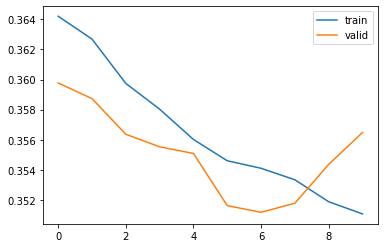

```python
# Capturing learning history per epoch
hist  = pd.DataFrame(history.history)
hist['epoch'] = history.epoch

# Plotting accuracy at different epochs
plt.plot(hist['loss'])
plt.plot(hist['val_loss'])
plt.legend(("train" , "valid") , loc =0)
```

## Evaluation

```python
score = model.evaluate(X_test, y_test)
```

- The model received as accuracy of .8420
- Need to see confusion matrix to know how well it predicted churn

```python
def make_confusion_matrix(cf,
                          group_names=None,
                          categories='auto',
                          count=True,
                          percent=True,
                          cbar=True,
                          xyticks=True,
                          xyplotlabels=True,
                          sum_stats=True,
                          figsize=None,
                          cmap='Blues',
                          title=None):
    '''
    This function will make a pretty plot of an sklearn Confusion Matrix cm using a Seaborn heatmap visualization.
    Arguments
    '''


    # CODE TO GENERATE TEXT INSIDE EACH SQUARE
    blanks = ['' for i in range(cf.size)]

    if group_names and len(group_names)==cf.size:
        group_labels = ["{}\n".format(value) for value in group_names]
    else:
        group_labels = blanks

    if count:
        group_counts = ["{0:0.0f}\n".format(value) for value in cf.flatten()]
    else:
        group_counts = blanks

    if percent:
        group_percentages = ["{0:.2%}".format(value) for value in cf.flatten()/np.sum(cf)]
    else:
        group_percentages = blanks

    box_labels = [f"{v1}{v2}{v3}".strip() for v1, v2, v3 in zip(group_labels,group_counts,group_percentages)]
    box_labels = np.asarray(box_labels).reshape(cf.shape[0],cf.shape[1])


    # CODE TO GENERATE SUMMARY STATISTICS & TEXT FOR SUMMARY STATS
    if sum_stats:
        #Accuracy is sum of diagonal divided by total observations
        accuracy  = np.trace(cf) / float(np.sum(cf))

        #if it is a binary confusion matrix, show some more stats
        if len(cf)==2:
            #Metrics for Binary Confusion Matrices
            precision = cf[1,1] / sum(cf[:,1])
            recall    = cf[1,1] / sum(cf[1,:])
            f1_score  = 2*precision*recall / (precision + recall)
            stats_text = "\n\nAccuracy={:0.3f}\nPrecision={:0.3f}\nRecall={:0.3f}\nF1 Score={:0.3f}".format(
                accuracy,precision,recall,f1_score)
        else:
            stats_text = "\n\nAccuracy={:0.3f}".format(accuracy)
    else:
        stats_text = ""


    # SET FIGURE PARAMETERS ACCORDING TO OTHER ARGUMENTS
    if figsize==None:
        #Get default figure size if not set
        figsize = plt.rcParams.get('figure.figsize')

    if xyticks==False:
        #Do not show categories if xyticks is False
        categories=False


    # MAKE THE HEATMAP VISUALIZATION
    plt.figure(figsize=figsize)
    sns.heatmap(cf,annot=box_labels,fmt="",cmap=cmap,cbar=cbar,xticklabels=categories,yticklabels=categories)

    if xyplotlabels:
        plt.ylabel('True label')
        plt.xlabel('Predicted label' + stats_text)
    else:
        plt.xlabel(stats_text)

    if title:
        plt.title(title)
```

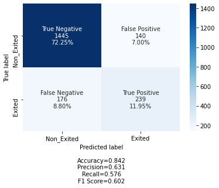

```python
## Confusion Matrix on unsee test set
import seaborn as sn
y_pred1 = model.predict(X_test)
for i in range(len(y_test)):
    if y_pred1[i]>0.5:
        y_pred1[i]=1
    else:
        y_pred1[i]=0



cm=confusion_matrix(y_test, y_pred1)
labels = ['True Negative','False Positive','False Negative','True Positive']
categories = [ 'Non_Exited','Exited']
make_confusion_matrix(cm,
                      group_names=labels,
                      categories=categories,
                      cmap='Blues')
```

- I believe that the bank would prefer to minimize the number of false positives, or the number of people predcited to leave that would have stayed. This way, resources are spent on things that are known to keep people from leaving
- Therefore, the Precision score will need to be optimized

### Adding weight initialization and early stopping

```python
#adding earlystopping callback
es= keras.callbacks.EarlyStopping(monitor='val_loss',
                              min_delta=0,
                              patience=15,

                             verbose=0, mode='min', restore_best_weights= True)
```

```python
# building a new model with weight initialization
Model2 = Sequential()
Model2.add(Dense(20, input_dim=12, kernel_initializer='he_normal', activation='relu'))
Model2.add(Dense(22, kernel_initializer='he_normal', activation='relu'))
#Dropout to avoid overfit
Model2.add(Dropout(0.5))
Model2.add(Dense(1, kernel_initializer='he_normal', activation='sigmoid'))

Model2.compile(optimizer='adam', loss='binary_crossentropy', metrics=['accuracy'])
```

```python
# fitting the new model
his_mod2= Model2.fit(X_train, y_train, validation_split=0.2, batch_size=100, epochs=40, callbacks=[es], shuffle=True, verbose=1)
```

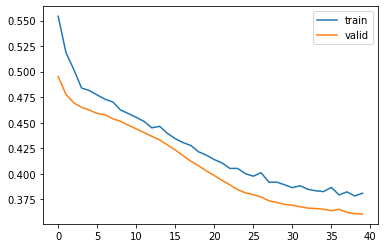

```python
# Capturing learning history per epoch
hist  = pd.DataFrame(his_mod2.history)
hist['epoch'] = his_mod2.epoch

# Plotting accuracy at different epochs
plt.plot(hist['loss'])
plt.plot(hist['val_loss'])
plt.legend(("train" , "valid") , loc =0)
```

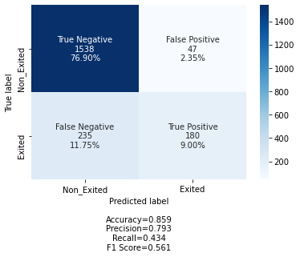

```python
y_pred1 = Model2.predict(X_test)
for i in range(len(y_test)):
    if y_pred1[i]>0.5:
        y_pred1[i]=1
    else:
        y_pred1[i]=0



cm2=confusion_matrix(y_test, y_pred1)
labels = ['True Negative','False Positive','False Negative','True Positive']
categories = [ 'Non_Exited','Exited']
make_confusion_matrix(cm2,
                      group_names=labels,
                      categories=categories,
                      cmap='Blues')
```

- Precision and accuracy were improved, but at the cost of recall and f1 score. False negatives will still be costly to the bank, as we will lose customers we could have otherwise kept, so this model will need to be improved

```python
# Model 3 is model 2 with more layers added and more neurons in each layer
# building a new model with weight initialization
Model3 = Sequential()
Model3.add(Dense(20, input_dim=12, kernel_initializer='he_normal', activation='relu'))
Model3.add(Dense(23, kernel_initializer='he_normal', activation='relu'))
#Dropout to avoid overfit
Model3.add(Dropout(0.5))
Model3.add(Dense(23, kernel_initializer='he_normal', activation='relu'))
Model3.add(Dense(23, kernel_initializer='he_normal', activation='relu'))
Model3.add(Dropout(0.5))
Model3.add(Dense(1, kernel_initializer='he_normal', activation='sigmoid'))

Model3.compile(optimizer='adam', loss='binary_crossentropy', metrics=['accuracy'])
```

```python
# fitting the new model
his_mod3= Model3.fit(X_train, y_train, validation_split=0.2, batch_size=100, epochs=40, callbacks=[es], shuffle=True, verbose=1)
```

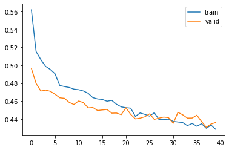

```python
# Capturing learning history per epoch
hist  = pd.DataFrame(his_mod3.history)
hist['epoch'] = his_mod3.epoch

# Plotting accuracy at different epochs
plt.plot(hist['loss'])
plt.plot(hist['val_loss'])
plt.legend(("train" , "valid") , loc =0)
```

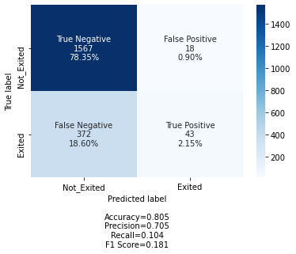

```python
y_pred1 = Model3.predict(X_test)
for i in range(len(y_test)):
    if y_pred1[i]>0.5:
        y_pred1[i]=1
    else:
        y_pred1[i]=0



cm3=confusion_matrix(y_test, y_pred1)
labels = ['True Negative','False Positive','False Negative','True Positive']
categories = [ 'Not_Exited','Exited']
make_confusion_matrix(cm3,
                      group_names=labels,
                      categories=categories,
                      cmap='Blues')
```

- Adding more layers and neurons made scores worse across the board
- Try with more layers and less neurons

```python
# Model 4 with more layers and less neurons
Model4 = Sequential()
Model4.add(Dense(8, input_dim=12, kernel_initializer='he_normal', activation='relu'))
Model4.add(Dense(10, kernel_initializer='he_normal', activation='relu'))


Model4.add(Dense(10, kernel_initializer='he_normal', activation='relu'))
Model4.add(Dense(10, kernel_initializer='he_normal', activation='relu'))

Model4.add(Dense(1, kernel_initializer='he_normal', activation='sigmoid'))

Model4.compile(optimizer='adam', loss='binary_crossentropy', metrics=['accuracy'])
```

```python
# fitting the new model
his_mod4= Model4.fit(X_train, y_train, validation_split=0.2, batch_size=100, epochs=40, callbacks=[es], shuffle=True, verbose=1)
```

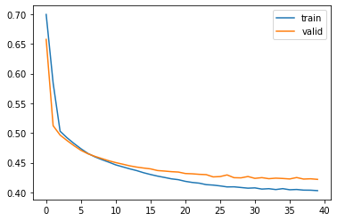

```python
# Capturing learning history per epoch
hist  = pd.DataFrame(his_mod4.history)
hist['epoch'] = his_mod4.epoch

# Plotting accuracy at different epochs
plt.plot(hist['loss'])
plt.plot(hist['val_loss'])
plt.legend(("train" , "valid") , loc =0)
```

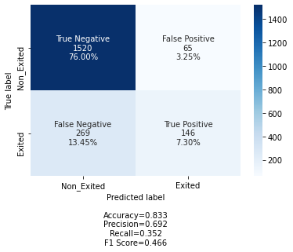

```python
y_pred1 = Model4.predict(X_test)
for i in range(len(y_test)):
    if y_pred1[i]>0.5:
        y_pred1[i]=1
    else:
        y_pred1[i]=0



cm4=confusion_matrix(y_test, y_pred1)
labels = ['True Negative','False Positive','False Negative','True Positive']
categories = [ 'Non_Exited','Exited']
make_confusion_matrix(cm4,
                      group_names=labels,
                      categories=categories,
                      cmap='Blues')
```

- Having more layers with less neurons resulted in worse performance
- It seems that model 2 still has the best scores

```python
# model5 based on model2 with softmax activation
Model5 = Sequential()
Model5.add(Dense(20, input_dim=12, kernel_initializer='he_normal', activation='softmax'))
Model5.add(Dense(22, kernel_initializer='he_normal', activation='softmax'))
#Dropout to avoid overfit
Model5.add(Dropout(0.5))
Model5.add(Dense(1, kernel_initializer='he_normal', activation='sigmoid'))

Model5.compile(optimizer='adam', loss='binary_crossentropy', metrics=['accuracy'])
```

```python
# fitting the new model
his_mod5= Model5.fit(X_train, y_train, validation_split=0.2, batch_size=100, epochs=40, callbacks=[es], shuffle=True, verbose=1)
```

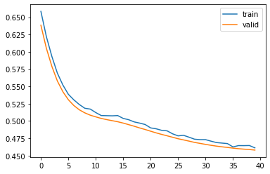

```python
# Capturing learning history per epoch
hist  = pd.DataFrame(his_mod5.history)
hist['epoch'] = his_mod5.epoch

# Plotting accuracy at different epochs
plt.plot(hist['loss'])
plt.plot(hist['val_loss'])
plt.legend(("train" , "valid") , loc =0)
```

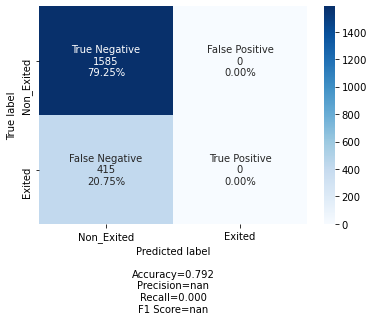

```python
y_pred1 = Model5.predict(X_test)
for i in range(len(y_test)):
    if y_pred1[i]>0.5:
        y_pred1[i]=1
    else:
        y_pred1[i]=0



cm5=confusion_matrix(y_test, y_pred1)
labels = ['True Negative','False Positive','False Negative','True Positive']
categories = [ 'Non_Exited','Exited']
make_confusion_matrix(cm5,
                      group_names=labels,
                      categories=categories,
                      cmap='Blues')
```

- For some reason, this model never predicted anyone would exit

## Conclusion

- In the end I was not able to produce a model with better Recall than model 2 that had the precision I wanted
- I would select Model2 as the final model